# Homework21035

Ma Haotian

2021-12-21

## 09-16

## Question

Use knitr to produce at least 3 examples (texts, figures, tables)

## Answer

#### 1.Use knitr to produce texts

In this part, I simply defined a variable with text information and printed it.

```r
text <- 'Welcome to statistical computing!'
text
```

```
## [1] "Welcome to statistical computing!"
```

#### 2.Use knitr to produce figures

In this part, firstly I defined two 30-unit variables, $X$ and $Y$, where $X_i\sim N(1,1)$ and $Y_i\sim N(1,0.5^2)$. Then I used ‘plot’ function to draw one scatter plot of $X$ and $Y$.

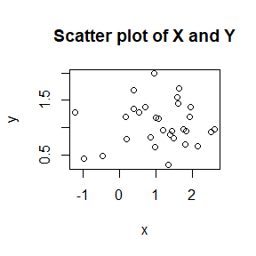

```r
set.seed(1)
x <- rnorm(30,1,1)
y <- rnorm(30,1,0.5)
plot(x,y,main = "Scatter plot of X and Y")
```

#### 3.Use knitr to produce tables

In this part, I printed two tables.

Firstly I printed the ‘state.x77’ dataset in a table. ‘State.x77’ includes data about population, income and so on of 50 states in the United States in 1977.

```r
state.x77.df <- data.frame(state.x77)
names(state.x77.df) <- c("Popul", "Income", "Illit", "LifeExp",
"Murder", "HSGrad", "Frost", "Area")
state.x77.df
```

```
##                Popul Income Illit LifeExp Murder HSGrad Frost   Area
## Alabama         3615   3624   2.1   69.05   15.1   41.3    20  50708
## Alaska           365   6315   1.5   69.31   11.3   66.7   152 566432
## Arizona         2212   4530   1.8   70.55    7.8   58.1    15 113417
## Arkansas        2110   3378   1.9   70.66   10.1   39.9    65  51945
## California     21198   5114   1.1   71.71   10.3   62.6    20 156361
## Colorado        2541   4884   0.7   72.06    6.8   63.9   166 103766
## Connecticut     3100   5348   1.1   72.48    3.1   56.0   139   4862
## Delaware         579   4809   0.9   70.06    6.2   54.6   103   1982
## Florida         8277   4815   1.3   70.66   10.7   52.6    11  54090
## Georgia         4931   4091   2.0   68.54   13.9   40.6    60  58073
## Hawaii           868   4963   1.9   73.60    6.2   61.9     0   6425
## Idaho            813   4119   0.6   71.87    5.3   59.5   126  82677
## Illinois       11197   5107   0.9   70.14   10.3   52.6   127  55748
## Indiana         5313   4458   0.7   70.88    7.1   52.9   122  36097
## Iowa            2861   4628   0.5   72.56    2.3   59.0   140  55941
## Kansas          2280   4669   0.6   72.58    4.5   59.9   114  81787
## Kentucky        3387   3712   1.6   70.10   10.6   38.5    95  39650
## Louisiana       3806   3545   2.8   68.76   13.2   42.2    12  44930
## Maine           1058   3694   0.7   70.39    2.7   54.7   161  30920
## Maryland        4122   5299   0.9   70.22    8.5   52.3   101   9891
## Massachusetts   5814   4755   1.1   71.83    3.3   58.5   103   7826
## Michigan        9111   4751   0.9   70.63   11.1   52.8   125  56817
## Minnesota       3921   4675   0.6   72.96    2.3   57.6   160  79289
## Mississippi     2341   3098   2.4   68.09   12.5   41.0    50  47296
## Missouri        4767   4254   0.8   70.69    9.3   48.8   108  68995
## Montana          746   4347   0.6   70.56    5.0   59.2   155 145587
## Nebraska        1544   4508   0.6   72.60    2.9   59.3   139  76483
## Nevada           590   5149   0.5   69.03   11.5   65.2   188 109889
## New Hampshire    812   4281   0.7   71.23    3.3   57.6   174   9027
## New Jersey      7333   5237   1.1   70.93    5.2   52.5   115   7521
## New Mexico      1144   3601   2.2   70.32    9.7   55.2   120 121412
## New York       18076   4903   1.4   70.55   10.9   52.7    82  47831
## North Carolina  5441   3875   1.8   69.21   11.1   38.5    80  48798
## North Dakota     637   5087   0.8   72.78    1.4   50.3   186  69273
## Ohio           10735   4561   0.8   70.82    7.4   53.2   124  40975
## Oklahoma        2715   3983   1.1   71.42    6.4   51.6    82  68782
## Oregon          2284   4660   0.6   72.13    4.2   60.0    44  96184
## Pennsylvania   11860   4449   1.0   70.43    6.1   50.2   126  44966
## Rhode Island     931   4558   1.3   71.90    2.4   46.4   127   1049
## South Carolina  2816   3635   2.3   67.96   11.6   37.8    65  30225
## South Dakota     681   4167   0.5   72.08    1.7   53.3   172  75955
## Tennessee       4173   3821   1.7   70.11   11.0   41.8    70  41328
## Texas          12237   4188   2.2   70.90   12.2   47.4    35 262134
## Utah            1203   4022   0.6   72.90    4.5   67.3   137  82096
## Vermont          472   3907   0.6   71.64    5.5   57.1   168   9267
## Virginia        4981   4701   1.4   70.08    9.5   47.8    85  39780
## Washington      3559   4864   0.6   71.72    4.3   63.5    32  66570
## West Virginia   1799   3617   1.4   69.48    6.7   41.6   100  24070
## Wisconsin       4589   4468   0.7   72.48    3.0   54.5   149  54464
## Wyoming          376   4566   0.6   70.29    6.9   62.9   173  97203
```

Then if we analyze this dataset using PCA method, the output can alse be shown in table as follows. All components’ sd and proprotion of variance were clear.

```r
state.pca <- princomp(state.x77.df, cor=T)
summary(state.pca,loadings=F)
```

```
## Importance of components:
##                           Comp.1    Comp.2    Comp.3     Comp.4     Comp.5
## Standard deviation     1.8970755 1.2774659 1.0544862 0.84113269 0.62019488
## Proportion of Variance 0.4498619 0.2039899 0.1389926 0.08843803 0.04808021
## Cumulative Proportion  0.4498619 0.6538519 0.7928445 0.88128252 0.92936273
##                            Comp.6    Comp.7     Comp.8
## Standard deviation     0.55449226 0.3800642 0.33643379
## Proportion of Variance 0.03843271 0.0180561 0.01414846
## Cumulative Proportion  0.96779544 0.9858515 1.00000000
```

## 09-23

## Question 3.4

Develop an algorithm to generate random samples from a Rayleigh($\sigma$) distribution. Generate Rayleigh($\sigma$) samples for several choices of $\sigma$ > 0 and check that the mode of the generated samples is close to the theoretical mode $\sigma$ (check the histogram).

## Answer 3.4

Since the Rayleigh pdf is $f(x)=\frac{x}{\sigma^2}e^{-x^2/2\sigma^2}$, the cdf then is $F(x)=1-e^{-x^2/2\sigma^2}$. Then $F^{-1}(u)=\sqrt {-2\sigma^2ln(1-u)}$.

I took the inverse transform method to generate random samples along with histogram check as following, where $\sigma$ values are 1, 2 and 4.

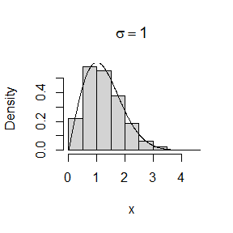

```r
# sigma = 1
set.seed(1)
sigma <- 1
n <- 1000
u <- runif(n)
x <- (-2*sigma^2*log(1-u))^0.5
hist(x, prob = TRUE, main = expression(sigma==1))
y <- seq(0,5,0.01)
lines(y,y/sigma^2*exp(1)^(-y^2/(2*sigma^2)))
```

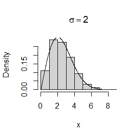

```r
# sigma = 2
sigma <- 2
x <- (-2*sigma^2*log(1-u))^0.5
hist(x, prob = TRUE, main = expression(sigma==2))
y <- seq(0,8,0.01)
lines(y,y/sigma^2*exp(1)^(-y^2/(2*sigma^2)))
```

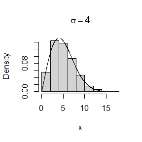

```r
# sigma = 4
sigma <- 4
x <- (-2*sigma^2*log(1-u))^0.5
hist(x, prob = TRUE, main = expression(sigma==4))
y <- seq(0,15,0.01)
lines(y,y/sigma^2*exp(1)^(-y^2/(2*sigma^2)))
```

All histogram checks shows that the mode of the generated samples is close to the theoretical mode $\sigma$.

## Question 3.11

Generate a random sample of size 1000 from a normal location mixture. The components of the mixture have $N(0, 1)$ and $N(3, 1)$ distributions with mixing probabilities $p_1$ and $p_2 = 1-p_1$. Graph the histogram of the sample with density superimposed, for $p_1 = 0.75$. Repeat with different values for $p_1$ and observe whether the empirical distribution of the mixture appears to be bimodal. Make a conjecture about the values of $p_1$ that produce bimodal mixtures.

## Answer 3.11

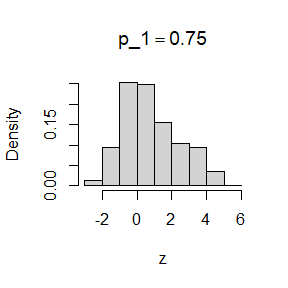

```r
# p_1 = 0.75
set.seed(2)
n <- 1000
x1 <- rnorm(n,0,1)
x2 <- rnorm(n,3,1)
p1 <- 0.75
p <- sample(c(1,0),n,TRUE,c(p1,1-p1))
z <- p*x1 + (1-p)*x2
hist(z, prob = TRUE, main = expression(p_1==0.75))
```

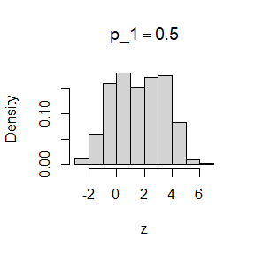

```r
# p_1 = 0.5
set.seed(2)
p1 <- 0.5
p <- sample(c(1,0),n,TRUE,c(p1,1-p1))
z <- p*x1 + (1-p)*x2
hist(z, prob = TRUE, main = expression(p_1==0.5))
```

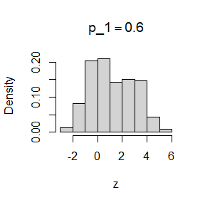

```r
# p_1 = 0.6
set.seed(2)
p1 <- 0.6
p <- sample(c(1,0),n,TRUE,c(p1,1-p1))
z <- p*x1 + (1-p)*x2
hist(z, prob = TRUE, main = expression(p_1==0.6))
```

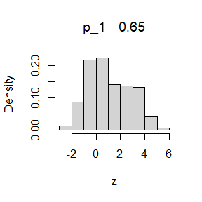

```r
# p_1 = 0.65
set.seed(2)
p1 <- 0.65
p <- sample(c(1,0),n,TRUE,c(p1,1-p1))
z <- p*x1 + (1-p)*x2
hist(z, prob = TRUE, main = expression(p_1==0.65))
```

When $p_1=0.5$ or $0.6$, the mixture is bimodal. When $p_1=0.75$ or $0.65$, the mixture is not bimodal.

I think the mixture appears to be bimodal as long as $p_1$ value is not far from $0.5$. When $p_1$ is too large or too small, i.e. far away from $0.5$, the mixture would not be bimodal.

## Question 3.11

A compound Poisson process is a stochastic process $\{X(t), t \geq 0\}$ that can be represented as the random sum $X(t) =\sum^ {N(t)}_ {i=1} Y_i$, $t \geq 0$, where $\{N(t), t \geq 0\}$ is a Poisson process and $Y_1, Y_2,...$ are $iid$ and independent of $\{N(t), t \geq 0\}$. Write a program to simulate a compound Poisson($\lambda$)-Gamma process ($Y$ has a Gamma distribution). Estimate the mean and the variance of $X(10)$ for several choices of the parameters and compare with the theoretical values.

Hint: Show that $E[X(t)] = \lambda tE[Y_1]$ and $Var(X(t)) = \lambda tE[Y_1^2]$

## Answer 3.11

Let $\{N(t), t \geq 0\} \sim Poisson(\lambda)$ and $Y\sim Gamma(r,\beta)$, where the values of $\lambda,$ $r$ and $\beta$ are 2, 4 and 3.

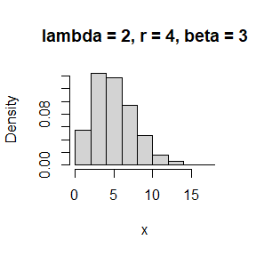

```r
# lambda = 2, r = 4, beta = 3
set.seed(3)
n <- 1000
lambda <- 2
r <- 4
beta <- 3
N <- vector(length = n)
for (i in 1:n) {
  N[i] <- rpois(1,lambda*i)
}
Y <- rgamma(max(N),r,beta)
X <- vector(length = n)
for (i in 1:n) {
  X[i] <- sum(Y[1:N[i]])
}
hist(x, prob = TRUE, main = 'lambda = 2, r = 4, beta = 3')
```

$$E[X(t)]=E[\sum_{i=1}^{N(t)}Y_i]=EE[\sum_{i=1}^{N(t)}Y_i|N(t)]=EE[N(t)*E[Y_1]|N(t)]=E[N(t)]E[Y_1]=\lambda tE[Y_1],$$
$$Var(X(t))=Var(E[\sum_{i=1}^{N(t)}Y_i|N(t)]) + E[Var(\sum_{i=1}^{N(t)}Y_i|N(t))]=Var(N(t)E[Y_1])+E[N(t)(EY_1^2-(EY_1)^2)]$$
$$=\lambda t(EY_1)^2+\lambda tEY_1^2-\lambda t(EY_1)^2=\lambda tEY_1^2 .$$

Then the theoretical mean and the variance of $X(10)$ are $\lambda*10*\frac{r}{\beta}=26.7$ and $\lambda*10*(\frac{r}{\beta^2}+(\frac{r}{\beta})^2)=44.4$

While their estimates can be got using real mean and variance of $Y_1,Y_2,...$ as follows.

```r
E <- mean(Y)
E2 <- mean(Y^2)
```

```r
lambda*10*E # estimate mean
```

```
## [1] 26.37981
```

```r
lambda*10*E2 # estimate variance
```

```
## [1] 43.86597
```

#### lamda = 4, r = 8 and beta = 6

```r
lambda <- 4
r <- 8
beta <- 6
N <- vector(length = n)
for (i in 1:n) {
  N[i] <- rpois(1,lambda*i)
}
Y <- rgamma(max(N),r,beta)
```

Then the theoretical mean and the variance of $X(10)$ are $\lambda*10*\frac{r}{\beta}=53.3$ and $\lambda*10*(\frac{r}{\beta^2}+(\frac{r}{\beta})^2)=80$

```r
E <- mean(Y)
E2 <- mean(Y^2)
```

```r
lambda*10*E # estimate mean
```

```
## [1] 54.05946
```

```r
lambda*10*E2 # estimate variance
```

```
## [1] 82.32137
```

#### lamda = 4, r = 2 and beta = 4

```r
lambda <- 4
r <- 2
beta <- 4
N <- vector(length = n)
for (i in 1:n) {
  N[i] <- rpois(1,lambda*i)
}
Y <- rgamma(max(N),r,beta)
```

Then the theoretical mean and the variance of $X(10)$ are $\lambda*10*\frac{r}{\beta}=20$ and $\lambda*10*(\frac{r}{\beta^2}+(\frac{r}{\beta})^2)=15$

```r
E <- mean(Y)
E2 <- mean(Y^2)
```

```r
lambda*10*E # estimate mean
```

```
## [1] 20.33887
```

```r
lambda*10*E2 # estimate variance
```

```
## [1] 15.37331
```

## 09-30

## Question 5.4

Write a function to compute a Monte Carlo estimate of the Beta(3, 3) cdf, and use the function to estimate $F(x)$ for x = 0.1, 0.2,…, 0.9. Compare the estimates with the values returned by the $pbeta$ function in R.

## Answer 5.4

```r
set.seed(1)
pdf <- function(x){x^2*(1-x)^2/beta(3,3)}
cdf <- function(x){
  U <- runif(1e4, 0, x)
  return(x*mean(pdf(U)))
}
```

```r
x <- seq(0.1,0.9,0.1)
MC <- vector(length = length(x))
for (i in 1:length(x)) {
  MC[i] <- cdf(x[i])
}
B <- pbeta(x,3,3)
print(round(rbind(x, MC, B), 9))
```

```
##           [,1]       [,2]      [,3]      [,4]      [,5]      [,6]     [,7]
## x  0.100000000 0.20000000 0.3000000 0.4000000 0.5000000 0.6000000 0.700000
## MC 0.008592357 0.05795302 0.1610569 0.3182425 0.5054814 0.6801827 0.838533
## B  0.008560000 0.05792000 0.1630800 0.3174400 0.5000000 0.6825600 0.836920
##         [,8]      [,9]
## x  0.8000000 0.9000000
## MC 0.9378992 0.9822031
## B  0.9420800 0.9914400
```

```r
# MC is estimate, B is real
```

The estimates and real value are very close.

## Question 5.9

Implement a function to generate samples from a $Rayleigh(\sigma)$ distribution, using antithetic variables. What is the percent reduction in variance of $\frac{X+X'}{2}$ compared with $\frac{X_1+X_2}{2}$ for independent $X_1, X_2$?

## Answer 5.9

Let $\sigma=1$, $f(x)=xe^{- \frac{x^2}{2}}$

```r
MC.Phi <- function(x, R = 10000, antithetic = TRUE) {
  u <- runif(R/2)
  if (!antithetic) v <- runif(R/2) else
    v <- 1 - u
  u <- c(u, v)
  cdf <- numeric(length(x))
  for (i in 1:length(x)) {
    g <- x[i] *u*x[i]* exp(-(u * x[i])^2 / 2)
    cdf[i] <- mean(g) + 0.5
  }
  cdf
}
```

```r
set.seed(1)
x <- seq(.1, 2.5, length=100)
MC1 <- MC.Phi(x, anti = FALSE)
MC2 <- MC.Phi(x)
(var(MC2)-var(MC1))/var(MC1)
```

```
## [1] 0.01331673
```

## Question 5.13

Find two importance functions $f_1$ and $f_2$ that are supported on x > 1 and are ‘close’ to
$$g(x) = \frac{x^2}{\sqrt {2\pi}}e^{-x^2/2}$$
Which of your two importance functions should produce the smaller variance in estimating
$$\int_1^{\infty} \frac{x^2}{\sqrt {2\pi}}e^{-x^2/2}dx$$
by importance sampling? Explain.

## Answer 5.13

I choose
$$f_1(x)=\frac{2}{\sqrt {2\pi}}e^{-(x-1)^2/2}$$
and
$$f_2(x)=e^{-x}$$

Clearly $f_1(x)$ is closer to $g(x)$. As a result $f_1$ would produce smaller variance in estimating
$$\int_1^{\infty} \frac{x^2}{\sqrt {2\pi}}e^{-x^2/2}dx.$$

## Question 5.14

Obtain a Monte Carlo estimate of
$$\int_1^{\infty} \frac{x^2}{\sqrt {2\pi}}e^{-x^2/2}dx$$
by importance sampling.

## Answer 5.14

I choose $f_2(x)=e^{-x}$ to be the importance function. $F_2(x)=1-e^{-x}$,$F^{-1}(u)=-ln(1-u)$,

$g(x)/f_2(x)=\frac{x^2}{\sqrt {2\pi}}e^{-x^2/2+x}$

```r
set.seed(1)
U <- runif(1e4)
X <- -log(1-U)
Y <- X^2/(2*3.14)^0.5 * exp(X-X^2/2)
mean(Y)
```

```
## [1] 0.4993853
```

## 10-14

## Question 6.5

Suppose a 95% symmetric t-interval is applied to estimate a mean, but the sample data are non-normal. Then the probability that the confidence interval covers the mean is not necessarily equal to 0.95. Use a Monte Carlo experiment to estimate the coverage probability of the t-interval for random samples of $\chi^2(2)$ data with sample size n = 20. Compare your t-interval results with the simulation results in Example 6.4. (The t-interval should be more robust to departures from normality than the interval for variance.)

## Answer 6.5

```r
set.seed(4)
X <- rchisq(20,2)
t.test(X,mu=2,conf.level = 0.95)
```

```
##
##  One Sample t-test
##
## data:  X
## t = 0.56566, df = 19, p-value = 0.5782
## alternative hypothesis: true mean is not equal to 2
## 95 percent confidence interval:
##  1.250399 3.304838
## sample estimates:
## mean of x
##  2.277618
```

```r
Y <- rchisq(1e4,2)
Z <- c()
for (i in 1:1e4) {
  Z[i] <- (Y[i]> 1.250399&&Y[i]<3.304838)
}
mean(Z) #coverage probability
```

```
## [1] 0.3521
```

The probability that the confidence interval covers the mean is not equal to 0.95.

As to 6.4,

```r
set.seed(1)
X <- rnorm(20)
t.test(X,mu=0,conf.level = 0.95)
```

```
##
##  One Sample t-test
##
## data:  X
## t = 0.93298, df = 19, p-value = 0.3625
## alternative hypothesis: true mean is not equal to 0
## 95 percent confidence interval:
##  -0.2368920  0.6179398
## sample estimates:
## mean of x
## 0.1905239
```

```r
set.seed(4)
Y <- rnorm(1e4)
Z <- c()
for (i in 1:1e4) {
  Z[i] <- (Y[i]> -0.2368920&&Y[i]<0.6179398)
}
mean(Z) #coverage probability
```

```
## [1] 0.325
```

The results are similar.

## Question 6.A

Use Monte Carlo simulation to investigate whether the empirical Type I error rate of the t-test is approximately equal to the nominal significance level $\alpha$, when the sampled population is non-normal. The t-test is robust to mild departures from normality. Discuss the simulation results for the cases where the sampled population is (i) $\chi^2(1)$, (ii) Uniform(0,2), and (iii) Exponential(rate=1). In each case, test $H_0 : \mu = \mu_0$ vs $H_1 : \mu \neq \mu_0$, where $mu_0$ is the mean of $\chi^2(1)$, Uniform(0,2), and Exponential(1), respectively.

## Answer 6.A

### (i)

$X$ from $\chi^2(1)$

```r
p <- vector(length = 1e4)
for (i in 1:1e4) {
  X <- rchisq(10,1)
  a <- t.test(X,mu = 1 ,conf.level = 0.9) #alpha = 0.1
  p[i] <- a$p.value
}
mean(p<=0.1)
```

```
## [1] 0.1807
```

Type I error rate of the t-test is bigger than $\alpha$.

### (ii)

$X$ from $Uniform(0,2)$

```r
p <- vector(length = 1e4)
for (i in 1:1e4) {
  X <- runif(10,0,2)
  a <- t.test(X,mu = 1,conf.level = 0.9)
  p[i] <- a$p.value
}
mean(p<=0.1)
```

```
## [1] 0.102
```

Type I error rate of the t-test is approximately equal to $\alpha$.

### (ii)

$X$ from $Exponential(1)$

```r
p <- vector(length = 1e4)
for (i in 1:1e4) {
  X <- rexp(10,1)
  a <- t.test(X,mu = 1,conf.level = 0.9)
  p[i] <- a$p.value
}
mean(p<=0.1)
```

```
## [1] 0.1557
```

Type I error rate of the t-test is bigger than $\alpha$.

## Question

If we obtain the powers for two methods under a particular simulation setting with 10,000 experiments: say, 0.651 for one method and 0.676 for another method. We want to know if the powers are different at 0.05 level.

## Answer

This is a hypothesis test problem about testing whether two benoulli’s p is equal or not.

We now have 10000 sample datasets for each of them and their sample $p$s, 0.651 and 0.676.

As a result, we can use two-sample t-test to finish this hypothesis test problem.

```r
X <- c(rep(1,6510),rep(0,3490))
Y <- c(rep(1,6760),rep(0,3240))
t.test(X,Y)
```

```
##
##  Welch Two Sample t-test
##
## data:  X and Y
## t = -3.7423, df = 19991, p-value = 0.0001828
## alternative hypothesis: true difference in means is not equal to 0
## 95 percent confidence interval:
##  -0.03809399 -0.01190601
## sample estimates:
## mean of x mean of y
##     0.651     0.676
```

From p-value = 0.0001828 we can come to the conclusion that in 0.99 level these 2 powers are different.

## 10-21

## Question of Example 6.8

Assess the Type $I$ error rate for a skewness test of normality at $\alpha$ = 0.05 based on the asymptotic distribution of $b_{1,d}$ for sample sizes n = 10, 20, 30, 50, 100, and 500.

## Answer

```r
d <- 2
n <- c(10, 20, 30 ,50, 100, 500) #sample sizes
cv <- qchisq(.95, d*(d+1)*(d+2)/6)*6/n #crit. values for each n
```

```r
b1d <- function(x) {
#computes the multivariate skewness statistic
  n <- nrow(x)
  x.bar <- colMeans(x)
  x.bar.matrix <- matrix(rep(x.bar,n),ncol = n,nrow = d)
  x.bar.matrix <- t(x.bar.matrix)
  sigma.hat <- cov(x)
  b <- ((x-x.bar.matrix) %*% solve(sigma.hat) %*% t(x-x.bar.matrix))^3
  b <- mean(b)
  return(b)
}
```

```r
library(MASS)
x.gener <- function(d,n){
#x generation process
  mean <- rep(0,d)
  sigma <- matrix(0,nrow = d,ncol = d)
  for (i in 1:d) {
    sigma[i,i] <- 1
  }
  x <- mvrnorm(n, mean, sigma)
}
```

```r
#p.reject <- numeric(length(n)) #to store sim. results
#m <- 10000

#for (i in 1:length(n)) {
#  sktests <- numeric(m) #test decisions
#  for (j in 1:m) {
#    x <- x.gener(d,n[i])
#    #test decision is 1 (reject) or 0
#    sktests[j] <- as.integer(abs(b1d(x)) >= cv[i] )
#  }
#  p.reject[i] <- mean(sktests) #proportion rejected
#}
#p.reject
#corresponding to n = 10, 20, 30, 50, 100, 500
```

## Question of Example 6.10

In this example, we estimate by simulation the power of the skewness test of normality against a contaminated normal (normal scale mixture) alternative described in Example 6.3

## Answer

```r
#set.seed(1)
#alpha <- .1
#n <- 500
#d <- 3
#m <- 2500
#epsilon <- c(seq(0, .15, .01), seq(.15, 1, .05))
#N <- length(epsilon)
#pwr <- numeric(N)

##critical value for the skewness test
#cv <- cv <- qchisq(.95, d*(d+1)*(d+2)/6)*6/n
#for (j in 1:N) { #for each epsilon
#  e <- epsilon[j]
#  sktests <- numeric(m)
#  for (i in 1:m) { #for each replicate
#    sigma1 <- diag(rep(1,d))
#    sigma2 <- diag(rep(10,d))
#    mean <- rep(0,d)
#    x1 <- mvrnorm(n, mean, sigma1)
#    x2 <- mvrnorm(n, mean, sigma2)
#    p <- sample(c(1,0),replace = TRUE, size = n*d,prob = c(1-e,e))
#    x <- x1*p+x2*(1-p)
#    sktests[i] <- as.integer(abs(b1d(x)) >= cv)
#  }
#  pwr[j] <- mean(sktests)
#}

##plot power vs epsilon
#plot(epsilon, pwr, type = "b",
#xlab = bquote(epsilon), ylim = c(0,0.8))
##abline(h = .1, lty = 3)
#se <- sqrt(pwr * (1-pwr) / m) #add standard errors
#lines(epsilon, pwr+se, lty = 3)
#lines(epsilon, pwr-se, lty = 3)
```

## 10-28

## Question 7.7

The five-dimensional scores data have a $5 \times 5$ covariance matrix $\Sigma$, with positive eigenvalues $\lambda_1 > ... > \lambda_5$. In principal components analysis,
$$\theta=\frac{\lambda_1}{\sum_{j=1}^5\lambda_j}$$
measures the proportion of variance explained by the first principal component. Let $\hat λ_1 > ··· > \hat λ_5$ be the eigenvalues of $\hat \Sigma$, where $\hat \Sigma$ is the MLE of $\Sigma$. Compute the sample estimate
$$\hat \theta=\frac{\hat \lambda_1}{\sum_{j=1}^5\hat \lambda_j}$$

## Answer 7.7

```r
library(bootstrap)
sigma.hat <- cov(scor)
lambda.hat <- eigen(sigma.hat)$values
theta.hat <- lambda.hat[1]/sum(lambda.hat)
theta.hat
```

```
## [1] 0.619115
```

## Question 7.8

Refer to Exercise 7.7. Obtain the jackknife estimates of bias and standard error of $\hat \theta$.

## Answer 7.8

```r
theta.jack <- numeric(nrow(scor))
for (i in 1:nrow(scor)) {
  data <- scor[-i,]
  sigma <- cov(data)
  lambda <- eigen(sigma)$values
  theta.jack[i] <- lambda[1]/sum(lambda)
}
bias <- (nrow(scor)-1)*(mean(theta.jack)-theta.hat)
bias
```

```
## [1] 0.001069139
```

```r
se <- sqrt((nrow(scor)-1)*mean((theta.jack-theta.hat)^2))
se
```

```
## [1] 0.04955244
```

## Question 7.9

Refer to Exercise 7.7. Compute 95% percentile and BCa confidence intervals for $\hat \theta$.

## Answer 7.9

```r
library(boot)
set.seed(1)
theta <- function(data,indices){
  d <- data[indices,]
  sigma.hat <- cov(d)
  lambda.hat <- eigen(sigma.hat)$values
  theta.hat <- lambda.hat[1]/sum(lambda.hat)
  return(theta.hat)
}
result <- boot(data = scor, statistic = theta, R=1000)
boot.ci(result,conf = 0.95,type = "bca")
```

```
## BOOTSTRAP CONFIDENCE INTERVAL CALCULATIONS
## Based on 1000 bootstrap replicates
##
## CALL :
## boot.ci(boot.out = result, conf = 0.95, type = "bca")
##
## Intervals :
## Level       BCa
## 95%   ( 0.5234,  0.7035 )
## Calculations and Intervals on Original Scale
```

## Question 7.B

Repeat Project 7.A for the sample skewness statistic. Compare the coverage rates for normal populations (skewness 0) and $\chi^2(5)$ distributions (positive skewness).

## Answer 7.B

#### Normal populations

```r
sk <- function(data,indices) {
#computes the sample skewness coeff.
  x <- data[indices]
  xbar <- mean(x)
  m3 <- mean((x - xbar)^3)
  m2 <- mean((x - xbar)^2)
  return( m3 / m2^1.5 )
}
getbc <- function(x){
  result <- boot(data = x,statistic = sk,R=1000)
  bc <- boot.ci(result,conf = 0.95,type = c("norm","basic","perc"))
  norm.ci <- c(bc$normal[2:3])
  basic.ci <- c(bc$basic[4:5])
  percent.ci <- c(bc$percent[4:5])
  matri <- as.matrix(rbind(rbind(norm.ci, basic.ci),percent.ci))
  return(matri)
}
```

```r
##Monte Carlo progress
#norm.cr <- numeric(1000)
#basic.cr <- numeric(1000)
#percent.cr <- numeric(1000)
#for (i in 1:1000) {
#  x <- rnorm(100)
#  ci <- getbc(x)
#  norm.cr[i] <- as.integer(0 < ci[1,2]&0 > ci[1,1])
#  basic.cr[i] <- as.integer(0 < ci[2,2]&0 > ci[2,1])
#  percent.cr[i] <- as.integer(0 < ci[3,2]&0 > ci[3,1])
#}
#norm.cr <- mean(norm.cr)
#norm.cr #coverage probabilities of the standard normal bootstrap confidence interval
```

```r
#basic.cr <- mean(basic.cr)
#basic.cr #coverage probabilities of the basic bootstrap confidence interval
```

```r
#percent.cr <- mean(percent.cr)
#percent.cr #coverage probabilities of the percentile confidence interval
```

#### chi^2(5) distributions

```r
#Monte Carlo progress
#norm.cr <- numeric(1000)
#basic.cr <- numeric(1000)
#percent.cr <- numeric(1000)
#for (i in 1:1000) {
#  x <- rchisq(100,df=5)
#  ci <- getbc(x)
#  norm.cr[i] <- as.integer(sqrt(8/5) < ci[1,2]& sqrt(8/5) > ci[1,1])
#  basic.cr[i] <- as.integer(sqrt(8/5) < ci[2,2]& sqrt(8/5) > ci[2,1])
#  percent.cr[i] <- as.integer(sqrt(8/5) < ci[3,2]& sqrt(8/5) > ci[3,1])
#}
#norm.cr <- mean(norm.cr)
#norm.cr #coverage probabilities of the standard normal bootstrap confidence interval
```

```r
#basic.cr <- mean(basic.cr)
#basic.cr #coverage probabilities of the basic bootstrap confidence interval
```

```r
#percent.cr <- mean(percent.cr)
#percent.cr #coverage probabilities of the percentile confidence interval
```

## 11-04

## Question 8.2

Implement the bivariate Spearman rank correlation test for independence [255] as a permutation test. The Spearman rank correlation test statistic can be obtained from function cor with method = “spearman”. Compare the achieved significance level of the permutation test with the p-value reported by cor.test on the same samples.

## Answer 8.2

```r
x <- rnorm(100)
y <- rnorm(100)
cor(x,y,method = "spearman")
```

```
## [1] -0.007488749
```

```r
cor.test(x,y)
```

```
##
##  Pearson's product-moment correlation
##
## data:  x and y
## t = -0.32846, df = 98, p-value = 0.7433
## alternative hypothesis: true correlation is not equal to 0
## 95 percent confidence interval:
##  -0.2280941  0.1643268
## sample estimates:
##         cor
## -0.03316168
```

## Question *

Design experiments for evaluating the performance of the NN, energy, and ball methods in various situations.

## Answer *

#### (1)Unequal variances and equal expectations

```r
# NN method
library(RANN)
library(boot)
Tn <- function(z, ix, sizes,k) {
    n1 <- sizes[1]; n2 <- sizes[2]; n <- n1 + n2
    if(is.vector(z)) z <- data.frame(z,0)
    z <- z[ix, ]
    NN <- nn2(data=z, k=k+1)
    block1 <- NN$nn.idx[1:n1,-1]
    block2 <- NN$nn.idx[(n1+1):n,-1]
    i1 <- sum(block1 < n1 + .5); i2 <- sum(block2 > n1+.5)
    (i1 + i2) / (k * n)
}
```

```r
#pow.nn <- numeric(length = 200)
#for (i in 1:200) {# monte carlo
#
#  x <- rnorm(30,0,1)
#  y <- rnorm(30,0,2)
#
#  z <- c(x, y)
#  N <- c(length(x), length(y))
#
#  boot.obj <- boot(data = z, statistic = Tn, R = 999,
#    sim = "permutation", sizes = N,k=3)
#  ts <- c(boot.obj$t0,boot.obj$t)
#  p.value <- mean(ts>=ts[1])
#  pow.nn[i] <- as.integer(p.value<0.05)
#}
#pow.nn <- mean(pow.nn)
#pow.nn #power of NN test
```

```r
# energy test
#library(energy)
#pow.energy <- numeric(length = 200)
#for (i in 1:200) {
#  x <- rnorm(30,0,1)
#  y <- rnorm(30,0,2)

#  z <- c(x,y)
#  N <- c(length(x), length(y))

#  boot.obs <- eqdist.etest(z, sizes=N, R=999)
#  p.value <- boot.obs$p.value

#  pow.energy[i] <- as.integer(p.value<0.05)
#}
#pow.energy <- mean(pow.energy)
#pow.energy # power of energy test
```

```r
# ball method
#library(Ball)
#pow.ball <- numeric(length = 200)
#for (i in 1:200) {
#  x <- rnorm(30,0,1)
#  y <- rnorm(30,0,2)

#  z <- c(x,y)
#  N <- c(length(x), length(y))

#  p.value = bd.test(x = x, y = y, num.permutations=999)$p.value

#  pow.ball[i] <- as.integer(as.numeric(p.value)<0.05)
#}
#pow.ball <- mean(pow.ball)
#pow.ball # power of ball method
```

```r
#data.frame(pow.nn,pow.energy,pow.ball)
```

#### (2)Unequal variances and unequal expectations

```r
# NN method
#pow.nn <- numeric(length = 200)
#for (i in 1:200) {# monte carlo
#  x <- rnorm(30,0,1)
#  y <- rnorm(30,0.5,2)

#  z <- c(x, y)
#  N <- c(length(x), length(y))

#  boot.obj <- boot(data = z, statistic = Tn, R = 999,
#    sim = "permutation", sizes = N,k=3)
#  ts <- c(boot.obj$t0,boot.obj$t)
#  p.value <- mean(ts>=ts[1])
#  pow.nn[i] <- as.integer(p.value<0.05)
#}
#pow.nn <- mean(pow.nn)
#pow.nn #power of NN test
```

```r
# energy test
#pow.energy <- numeric(length = 200)
#for (i in 1:200) {
#  x <- rnorm(30,0,1)
#  y <- rnorm(30,0.5,2)

#  z <- c(x,y)
#  N <- c(length(x), length(y))

#  boot.obs <- eqdist.etest(z, sizes=N, R=999)
#  p.value <- boot.obs$p.value

#  pow.energy[i] <- as.integer(p.value<0.05)
#}
#pow.energy <- mean(pow.energy)
#pow.energy # power of energy test
```

```r
# ball method
#pow.ball <- numeric(length = 200)
#for (i in 1:200) {
#  x <- rnorm(30,0,1)
#  y <- rnorm(30,0.5,2)

#  z <- c(x,y)
#  N <- c(length(x), length(y))

#  p.value = bd.test(x = x, y = y, num.permutations=999)$p.value

#  pow.ball[i] <- as.integer(as.numeric(p.value)<0.05)
#}
#pow.ball <- mean(pow.ball)
#pow.ball # power of ball method
```

```r
#data.frame(pow.nn,pow.energy,pow.ball)
```

#### (3)Non-normal distributions: t distribution with 1 df, bimodel distribution

```r
# NN method
#pow.nn <- numeric(length = 200)
#for (i in 1:200) {# monte carlo
#  x <- rt(30,df=1)
#  y1 <- rnorm(30,0,1)
#  y2 <- rnorm(30,0,2)
#  p <- sample(c(0,1),size = 1)
#  y <- p*y1+(1-p)*y2
#
#  z <- c(x, y)
#  N <- c(length(x), length(y))
#
#  boot.obj <- boot(data = z, statistic = Tn, R = 999,
#    sim = "permutation", sizes = N,k=3)
#  ts <- c(boot.obj$t0,boot.obj$t)
#  p.value <- mean(ts>=ts[1])
#  pow.nn[i] <- as.integer(p.value<0.05)
#}
#pow.nn <- mean(pow.nn)
#pow.nn #power of NN test
```

```r
# energy test
#pow.energy <- numeric(length = 200)
#for (i in 1:1000) {
#  x <- rt(30,df=1)
#  y1 <- rnorm(30,0,1)
#  y2 <- rnorm(30,0,2)
#  p <- sample(c(0,1),size = 1)
#  y <- p*y1+(1-p)*y2
#
#  z <- c(x,y)
#  N <- c(length(x), length(y))
#
#  boot.obs <- eqdist.etest(z, sizes=N, R=999)
#  p.value <- boot.obs$p.value
#
#  pow.energy[i] <- as.integer(p.value<0.05)
#}
#pow.energy <- mean(pow.energy)
#pow.energy # power of energy test
```

```r
# ball method
#pow.ball <- numeric(length = 200)
#for (i in 1:1000) {
#  x <- rt(30,df=1)
#  y1 <- rnorm(30,0,1)
#  y2 <- rnorm(30,0,2)
#  p <- sample(c(0,1),size = 1)
#  y <- p*y1+(1-p)*y2
#
#  z <- c(x,y)
#  N <- c(length(x), length(y))
#
#  p.value = bd.test(x = x, y = y, num.permutations=999)$p.value
#
#  pow.ball[i] <- as.integer(as.numeric(p.value)<0.05)
#}
#pow.ball <- mean(pow.ball)
#pow.ball # power of ball method
```

```r
#data.frame(pow.nn,pow.energy,pow.ball)
```

#### (4)Unbalanced samples

```r
# NN method
#pow.nn <- numeric(length = 200)
#for (i in 1:200) {# monte carlo
#  x <- rnorm(10,0,1)
#  y <- rnorm(50,1,2)
#
#  z <- c(x, y)
#  N <- c(length(x), length(y))
#
#  boot.obj <- boot(data = z, statistic = Tn, R = 999,
#    sim = "permutation", sizes = N,k=3)
#  ts <- c(boot.obj$t0,boot.obj$t)
#  p.value <- mean(ts>=ts[1])
#  pow.nn[i] <- as.integer(p.value<0.05)
#}
#pow.nn <- mean(pow.nn)
#pow.nn #power of NN test
```

```r
# energy test
#pow.energy <- numeric(length = 200)
#for (i in 1:200) {
#  x <- rnorm(10,0,1)
#  y <- rnorm(50,1,2)
#
#  z <- c(x,y)
#  N <- c(length(x), length(y))
#
#  boot.obs <- eqdist.etest(z, sizes=N, R=999)
#  p.value <- boot.obs$p.value
#
#  pow.energy[i] <- as.integer(p.value<0.05)
#}
#pow.energy <- mean(pow.energy)
#pow.energy # power of energy test
```

```r
# ball method
#pow.ball <- numeric(length = 200)
#for (i in 1:200) {
#  x <- rnorm(10,0,1)
#  y <- rnorm(50,1,2)
#
#  z <- c(x,y)
#  N <- c(length(x), length(y))
#
#  p.value = bd.test(x = x, y = y, num.permutations=999)$p.value
#
#  pow.ball[i] <- as.integer(as.numeric(p.value)<0.05)
#}
#pow.ball <- mean(pow.ball)
#pow.ball # power of ball method
```

```r
#data.frame(pow.nn,pow.energy,pow.ball)
```

## 11-11

## Question 9.3

Use the Metropolis-Hastings sampler to generate random variables from a standard Cauchy distribution. Discard the first 1000 of the chain, and compare the deciles of the generated observations with the deciles of the standard Cauchy distribution (see qcauchy or qt with df=1).

## Answer 9.3

```r
options (warn = -1)
f <- function(x){ # target pdf
  return(1/(pi*(1+x^2)))
}

g <- function(a,b){#g(a|b), proposal pdf
  return(dnorm(a,b))
}

set.seed(2)
X <- numeric(length = 10000)
X[1] <- 0

for (i in 2:16000) {
  Y <- rnorm(1,X[i-1])
  U <- runif(1)
  alpha <- f(Y)*g(X[i-1],Y)/(f(X[i-1])*g(Y,X[i-1]))
  if(U<=alpha)X[i] <- Y else X[i] <- X[i-1]
}
X <- X[-(1:1000)]
```

Comparing deciles:

```r
df <- data.frame(qt=qt((1:9)/10,df=1),X=quantile(X, probs = (1:9)/10))
rownames(df) <- c("0.1","0.2","0.3","0.4","0.5","0.6","0.7","0.8","0.9")
df
```

```
##             qt           X
## 0.1 -3.0776835 -3.52350290
## 0.2 -1.3763819 -1.42558005
## 0.3 -0.7265425 -0.74329871
## 0.4 -0.3249197 -0.33813613
## 0.5  0.0000000 -0.01746655
## 0.6  0.3249197  0.27091854
## 0.7  0.7265425  0.61403023
## 0.8  1.3763819  1.19396517
## 0.9  3.0776835  2.51046712
```

Their deciles are similar.

## Question 9.8

Consider the bivariate density
$$f(x,y)\approx(_x^n)y^{x+a-1}(1-y)^{n-x+b-1},x=0,1...,n,0\leq y\leq 1$$
It can be shown (see e.g. [23]) that for fixed a, b, n, the conditional distributions are Binomial(n, y) and Beta(x + a, n − x + b). Use the Gibbs sampler to generate a chain with target joint density f(x, y).

## Answer 9.8

```r
n <- 5
a <- 2
b <- 3
```

```r
X <- numeric(length = 1000)
Y <- numeric(length = 1000)
X[1] <- 1
Y[1] <- 1

for (i in 2:1000) {
  Y[i] <- rbeta(1,X[i-1]+a,n-X[i-1]+b)
  X[i] <- rbinom(1,n,Y[i])
}
```

Select 10 units to display as follows.

```r
data.frame(X=X[701:710],Y=Y[701:710])
```

```
##    X         Y
## 1  3 0.6655227
## 2  2 0.4938351
## 3  2 0.2477856
## 4  5 0.6495848
## 5  2 0.6678237
## 6  2 0.5624496
## 7  1 0.3919249
## 8  1 0.1986792
## 9  1 0.2545175
## 10 2 0.2225551
```

## Question *

For each of the above exercise, use the Gelman-Rubin method to monitor convergence of the chain, and run the chain until it converges approximately to the target distribution according to $\hat R < 1.2$

## Answer *

#### 9.3

```r
# k chains
# n units each chain

getX <- function(n){
  k <- 100
  X <- matrix(nrow = n,ncol = k) # one colomn is one chain
  for (i in 1:k) {
    X[1,i] <- rnorm(1)
    for (j in 2:n) {
      Y <- rnorm(1,X[j-1,i])
      U <- runif(1)
      alpha <- f(Y)*g(X[j-1,i],Y)/(f(X[j-1,i])*g(Y,X[j-1,i]))
      if(U<=alpha)X[j,i] <- Y else X[j,i] <- X[j-1,i]
    }
  }
  return(X)
}
```

```r
# phi_in is X[,i]
# phi_i,j is X[j,i]

getR.hat <- function(n){
  k <- 100
  X <- getX(n)

  Xbar <- mean(X)
  Bn <- 0
  for (i in 1:k) {
    Bn <- Bn + (mean(X[,i])-Xbar)^2
  }
  Bn <- n*Bn/(k-1)

  Wn <- 0
  for (i in 1:k) {
    for (j in 1:n) {
      Wn <- Wn + (X[j,i]-mean(X[,i]))^2
    }
  }
  Wn <- Wn/n/k

  var.hat <- (n-1)*Wn/n + Bn/n
  R.hat <- var.hat/Wn
  return(R.hat)
}
```

```r
getR.hat(100)
```

```
## [1] 1.8138
```

#### 9.8

```r
k <- 10   # k chains
n <- 100 # n units each chain

n. <- 5
a <- 2
b <- 3
```

```r
X <- matrix(nrow = n,ncol = k) # one colomn is one chain
Y <- matrix(nrow = n,ncol = k) # one colomn is one chain
X[1] <- 1
Y[1] <- 1

for (j in 1:k) {
  X[1,j] <- 1
  Y[1,j] <- 1

  for (i in 2:n) {
    Y[i,j] <- rbeta(1,X[i-1,j]+a,n.-X[i-1,j]+b)
    X[i,j] <- rbinom(1,n.,Y[i,j])
  }
}
```

Monitoring X:

```r
Xbar <- mean(X)
Bn.X <- 0
for (i in 1:k) {
  Bn.X <- Bn.X + (mean(X[,i])-Xbar)^2
}
Bn.X <- n*Bn.X/(k-1)
```

```r
Wn.X <- 0
for (i in 1:k) {
  for (j in 1:n) {
    Wn.X <- Wn.X + (X[j,i]-mean(X[,i]))^2
  }
}
Wn.X <- Wn.X/n/k
```

```r
var.hat.X <- (n-1)*Wn.X/n + Bn.X/n
R.hat.X <- var.hat.X/Wn.X
R.hat.X
```

```
## [1] 1.03295
```

$\hat R_X$ is smaller than 1.2, so the chain converges.

Monitoring Y:

```r
options (warn = -1)
Ybar <- mean(Y)
Bn.Y <- 0
for (i in 1:k) {
  Bn.Y <- Bn.Y + (mean(Y[,i])-Ybar)^2
}
Bn.Y <- n*Bn.Y/(k-1)
```

```r
Wn.Y <- 0
for (i in 1:k) {
  for (j in 1:n) {
    Wn.Y <- Wn.Y + (Y[j,i]-mean(Y[,i]))^2
  }
}
Wn.Y <- Wn.Y/n/k
```

```r
var.hat.Y <- (n-1)*Wn.Y/n + Bn.Y/n
R.hat.Y <- var.hat.Y/Wn.Y
R.hat.Y
```

```
## [1] 1.019416
```

$\hat R_Y$ is smaller than 1.2, so the chain converges.

## 11-18

## Question 11.3

(a)Write a function to compute the kth term in a sum function, where d $\geq$ 1 is an integer, $a$ is a vector in $R^d$, and $|·|$denotes the Euclidean norm. Perform the arithmetic so that the coefficients can be computed for (almost) arbitrarily large k and d. (This sum converges for all $a \in R^d$)

(b)Modify the function so that it computes and returns the sum.

3. Evaluate the sum when $a = (1, 2)^T$

## Answer 11.3

#### (a)

```r
fk <- function(k,d,a){

  return(   (-1)^k * exp( log(sum(a^2)^(k+1))+lgamma((d+1)/2)+lgamma(k+3/2) - lgamma(k+1)-log(2^k)-log(2*k+1)-log(2*k+2)-lgamma(k+d/2+1) )    )


}
```

Let k=10, d=5, a= rep(1,5)

```r
fk(10,5,rep(1,5))
```

```
## [1] 3.957193e-07
```

Let k=50, d=10, a= rep(1,10)

```r
fk(50,10,rep(1,10))
```

```
## [1] 2.532068e-39
```

Let k=100, d=20, a= rep(1,20)

```r
fk(100,20,rep(1,20))
```

```
## [1] 3.527969e-75
```

Let k=200, d=30, a= rep(1,30)

```r
fk(200,30,rep(1,30))
```

```
## [1] 3.145816e-166
```

#### (b)

```r
f <- function(d,a){

  index <- 1
  while (fk(index,d,a>1e-16)) {
    index <- index + 1
  }

  sum <- 0
  for (i in 1:index) {
    sum <- sum + fk(i,d,a)
  }
  return(sum)
}
```

#### (c)

```r
f(d=2,a=c(1,2))
```

```
## [1] -0.4313314
```

## Question 11.5

Write a function to solve the equation for a. Compare the solutions with the points A(k) in Exercise 11.4.

## Answer 11.5

```r
f1 <- function(u,a){
  (1+u^2/(k-1))^(-k/2)
}
f2 <- function(u,a){
  (1+u^2/k)^(-(k+1)/2)
}

f <- function(a){
  2*exp(lgamma(k/2)-log(pi*(k-1))/2-lgamma((k-1)/2))*integrate(f1,lower = 0,upper = (a^2*(k-1)/(k-a^2))^(1/2),a=a)$value  -  2*exp( lgamma((k+1)/2)-log(pi*k)/2-lgamma(k/2)*integrate(f2,lower = 0,upper = (a^2*k/(k+1-a^2))^(1/2),a=a)$value  )

}
```

```r
k_value <- c(4:25,100,500,1000)
A <- c()
for (i in 1:length(k_value)) {
  k <- k_value[i]
  res <- uniroot(f,c(0,2))
  A[i] <- unlist(res)[1]
}
data.frame(k=k_value,A_k=A)
```

```
##       k      A_k
## 1     4 1.269415
## 2     5 1.264324
## 3     6 1.262542
## 4     7 1.262440
## 5     8 1.262965
## 6     9 1.263725
## 7    10 1.264515
## 8    11 1.265270
## 9    12 1.265953
## 10   13 1.266592
## 11   14 1.267128
## 12   15 1.267625
## 13   16 1.268050
## 14   17 1.268477
## 15   18 1.268842
## 16   19 1.269173
## 17   20 1.269474
## 18   21 1.269749
## 19   22 1.270002
## 20   23 1.270234
## 21   24 1.270448
## 22   25 1.270646
## 23  100 1.274294
## 24  500 1.275272
## 25 1000 1.275405
```

As to 11.4,

```r
# 11.4
f <- function(a){
  pt((a^2*(k-1)/(k-a^2))^(1/2),df=k-1) - pt((a^2*k/(k+1-a^2))^(1/2),df=k)
}
```

```r
#k_value <- c(4:25,100,500,1000)
#A <- c()
#for (i in 1:length(k_value)) {
#  k <- k_value[i]
#  res <- uniroot(f,c(0,k^(1/2)))
#  A[i] <- unlist(res)[1]
#}
#data.frame(k=k_value,A_k=A)
```

```r
k <- 9
res <- uniroot(f,c(0,k^(1/2)))
unlist(res)
```

```
##       root     f.root       iter    init.it estim.prec
##          0          0          0         NA          0
```

## Question *

Use the E-M algorithm to estimate $\lambda$, compare your result with the observed data MLE.

## Answer *

EM algorithm:

```r
y <- c(0.54,0.48,0.33,0.43,0.91,0.21,0.85)
x <- c(1,1,1)
```

```r
lambda <- mean(c(x,y))
lambda_new <- lambda+1
while (abs(lambda-lambda_new)>1e-16) {
  lambda_new <- lambda
  # E step
  x <- rep(1+lambda_new,3)

  # M step
  lambda <- mean(c(x,y))

}
lambda
```

```
## [1] 0.9642857
```

MLE:

```r
mean(y)
```

```
## [1] 0.5357143
```

The MLE estimate is much smaller than EM’s result.

## 11-25

## Question page-204.1

Why are the following two invocations of lapply() equivalent?

trims <- c(0, 0.1, 0.2, 0.5); x <- rcauchy(100)

lapply(trims, function(trim) mean(x, trim = trim)); lapply(trims, mean, x = x)

## Answer page-204.1

The ‘mean’ function has 2 input parameters, ‘x’ and ‘trim’.

Recall that ’lapply’s inputs: X, FUN, …

X will be used as the first paramater of FUN.

In the question, the second sentence added an ‘x’ after ‘mean’, leading to the first parameter of mean is input by ‘x’. As a result, ‘trims’ will be input to ‘mean’ as the second parameter. So the final result is the same as the first one in the question.

## Question page-204.5

For each model in the previous two exercises, extract $R^2$ using the function below.

rsq <- function(mod) summary(mod)$r.squared

## Answer page-204.5

```r
rsq <- function(mod) summary(mod)$r.squared
```

```r
# 3.
formulas <- list(
  mpg ~ disp,
  mpg ~ I(1 / disp),
  mpg ~ disp + wt,
  mpg ~ I(1 / disp) + wt
)
f <- function(formula){
  mod <- lm(formula,mtcars)
  return(rsq(mod))
}
lapply(formulas, f)
```

```
## [[1]]
## [1] 0.7183433
##
## [[2]]
## [1] 0.8596865
##
## [[3]]
## [1] 0.7809306
##
## [[4]]
## [1] 0.8838038
```

```r
# 4.
bootstraps <- lapply(1:10, function(i) {
  rows <- sample(1:nrow(mtcars), rep = TRUE)
  mtcars[rows, ]
})


rsq <- function(data){
  mod <- lm(mpg~disp,data=data)
  return(summary(mod)$r.squared)
}
```

```r
# lapply
lapply(bootstraps, rsq)
```

```
## [[1]]
## [1] 0.6774122
##
## [[2]]
## [1] 0.8061072
##
## [[3]]
## [1] 0.7997079
##
## [[4]]
## [1] 0.7067493
##
## [[5]]
## [1] 0.7078747
##
## [[6]]
## [1] 0.7774177
##
## [[7]]
## [1] 0.7200399
##
## [[8]]
## [1] 0.7406424
##
## [[9]]
## [1] 0.7799331
##
## [[10]]
## [1] 0.6794392
```

```r
# for loop
for (i in 1:10) {
  data <- as.data.frame(bootstraps[i])
  print(rsq(data))
}
```

```
## [1] 0.6774122
## [1] 0.8061072
## [1] 0.7997079
## [1] 0.7067493
## [1] 0.7078747
## [1] 0.7774177
## [1] 0.7200399
## [1] 0.7406424
## [1] 0.7799331
## [1] 0.6794392
```

## Question page-214.1

#### (a)

```r
x <- data.frame(x1=rnorm(10),x2=rchisq(10,2),x3=runif(10))
x # dataframe
```

```
##              x1        x2         x3
## 1   1.463768513 0.6019313 0.21232575
## 2   0.081306274 3.6924660 0.05007734
## 3   0.504534470 0.8750699 0.88091761
## 4  -0.596404637 2.5920147 0.70236820
## 5  -0.291344310 0.2238821 0.64448458
## 6   0.761717367 0.9633371 0.41528600
## 7  -0.004973426 0.9139509 0.29830427
## 8   0.749788634 2.2505951 0.18822052
## 9   0.136399851 5.3174652 0.57226929
## 10 -1.803829470 2.3865225 0.77191764
```

```r
round(vapply(x,sd,FUN.VALUE = c(sd= 1)),3)
```

```
##    x1    x2    x3
## 0.892 1.601 0.281
```

#### (b)

```r
x <- data.frame(x1=letters[1:10],x2=rnorm(10),x3=runif(10),x4=letters[11:20])
x # dataframe
```

```
##    x1         x2        x3 x4
## 1   a -0.2653786 0.8999494  k
## 2   b -2.1517036 0.9377632  l
## 3   c  0.6403688 0.4760684  m
## 4   d -1.3978768 0.2025054  n
## 5   e -0.4066723 0.3035708  o
## 6   f  0.5712266 0.7295225  p
## 7   g -1.1425464 0.6966989  q
## 8   h  0.8477663 0.5029945  r
## 9   i -0.3937813 0.9265270  s
## 10  j  0.1627073 0.5308530  t
```

```r
round(vapply(x[which(vapply(x, is.numeric, FUN.VALUE = 1)==1)], sd, FUN.VALUE = c(sd=1)),3)
```

```
##    x2    x3
## 0.972 0.260
```

## Question page-214.7

Implement mcsapply(), a multicore version of sapply(). Can you implement mcvapply(), a parallel version of vapply()? Why or why not?

## Answer page-214.7

```r
# mcsapply
library(parallel)
mcsapply <- function(X, FUN, ..., simplify = TRUE,USE.NAMES = TRUE, mc.cores=2){

  cl <- makeCluster(cores)
  res <- parSapply(cl,X,FUN,...,simplify = simplify, USE.NAMES = USE.NAMES)
  stopCluster(cl)

  return(res)
}
```

## 12-02

## Question 1.

Write an Rcpp function for Exercise 9.8 (page 278, Statistical Computing with R)

## Answer 1.

```r
# gibbs in rcpp
library(Rcpp)
cppFunction('

NumericMatrix gibbs_cpp(int n, int a, int b){
  NumericMatrix df(10000,2);
  NumericVector X(10000);
  NumericVector Y(10000);
  NumericVector temp(1);

  X[0]=1;
  Y[0]=1;

  for (int i=1;i<10000;i++){
    temp=rbeta(1,X[i-1]+a,n-X[i-1]+b);
    Y[i]=temp[0];
    temp=rbinom(1,n,Y[i]);
    X[i]=temp[0];
  }

  df(_,0)=X;
  df(_,1)=Y;

  return df;
}

')
```

```r
data_cpp <- gibbs_cpp(5,2,3)
# 1st column is X, 2nd column is Y
```

## Question 2.

Compare the corresponding generated random numbers with pure R language using the function “qqplot”.

## Answer 2.

```r
# gibbs in r
gibbs_r <- function(n,a,b){
  X <- numeric(length = 10000)
  Y <- numeric(length = 10000)
  X[1] <- 1
  Y[1] <- 1

  for (i in 2:10000) {
    Y[i] <- rbeta(1,X[i-1]+a,n-X[i-1]+b)
    X[i] <- rbinom(1,n,Y[i])
  }

  return(data.frame(X=X,Y=Y))
}
```

```r
data_r <- gibbs_r(5,2,3)
```

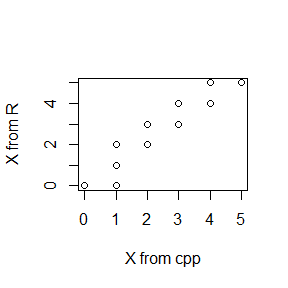

```r
qqplot(x=data_cpp[,1],y=data_r$X,xlab = 'X from cpp',ylab = 'X from R')
```

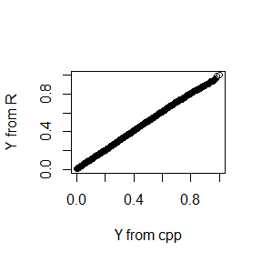

```r
qqplot(x=data_cpp[,2],y=data_r$Y,xlab = 'Y from cpp',ylab = 'Y from R')
```

## Question 3.

Campare the computation time of the two functions with the function “microbenchmark”.

## Answer 3.

```r
library(microbenchmark)
ts <- microbenchmark(gibbsR=gibbs_r(5,2,3),gibbsC=gibbs_cpp(5,2,3))
summary(ts)[,c(1,3,5,6)]
```

```
##     expr        lq    median       uq
## 1 gibbsR 43.139551 45.339301 49.45120
## 2 gibbsC  4.247001  4.496051  4.77775
```

The computation time Cpp spent is significantly less than R.

## Question 4.

Comments your results.

## Answer 4.

From qqplot we found that the data generated from Cpp and R were from the similar or same distribution. In other words, Cpp performs as well as R in terms of data quality.

However, from the results of function ‘microbenchmark’ we can come to the conclusion that Cpp saves much more time for computing. In our daily scientific research, we can make full use of this advantage of Cpp to improve our efficiency.